# Contents

1. Cut Size Minimization
2. Hierarchical Clustering
3. From Partitions to Communities
4. Modularity Maximization

```python
import networkx as nx
import numpy as np
import matplotlib as mpl
import matplotlib.pyplot as plt
%matplotlib inline

from matplotlib.cm import gist_rainbow_r as cmap
cyan, yellow, magenta = map(cmap, [.4, .8, 0])
```

In this tutorial, I am going to demonstrate graph partitioning and community dection with four real networks and some toy networks; all networks are assumed undirected and unweighted. I encourage you to play with these networks and see if you can discover something interesting.

The first real network is a striking trade union [1], which consists of 4 young Spanish speakers (yellow sawtooth), 9 young English speakers (white sawtooth), and 11 old English speakers (white round). An edge between two members indicates that they often talked to each other about the strike. The company tried to resolve the strike by negotiating with Sam and Wendle (thick border), but they found this strategy completely ineffective.

```
Number of nodes: 24
Number of edges: 38
```

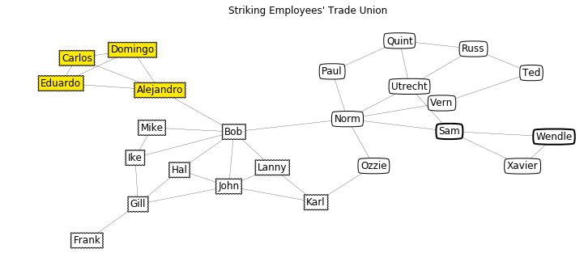

```python
strike = nx.Graph()
edges = [( 1,11), ( 1,15), ( 2, 5), ( 2, 7), ( 2,10), ( 2,15), ( 3,17), ( 4,20), ( 4,21), ( 4,23),
         ( 5, 9), ( 5,12), ( 5,15), ( 5,16), ( 5,22), ( 6, 9), ( 6,17), ( 6,24), ( 7,10), ( 7,14),
         ( 8,12), ( 8,18), ( 8,24), ( 9,13), ( 9,18), ( 9,19), ( 9,21), ( 9,24), (10,22), (11,15),
         (13,17), (13,19), (14,16), (17,24), (18,24), (20,21), (20,23), (21,23)]
names = ['Xavier', 'Utrecht', 'Frank', 'Domingo', 'Norm', 'Hal', 'Russ', 'Karl',
         'Bob', 'Quint', 'Wendle', 'Ozzie','Ike', 'Ted', 'Sam', 'Vern',
         'Gill', 'Lanny', 'Mike', 'Carlos', 'Alejandro', 'Paul', 'Eduardo', 'John']
strike.add_edges_from(edges)
strike = nx.relabel_nodes(strike, dict((i+1, n) for i,n in enumerate(names)))
for n,d in strike.nodes(data=True):
    d['lang'] = 'Spanish' if n in ['Carlos', 'Domingo', 'Eduardo', 'Alejandro'] \
           else 'English'
    d['old'] = n in ['Ozzie', 'Norm', 'Paul', 'Quint', 'Russ', 'Ted',
                     'Utrecht', 'Vern', 'Sam', 'Wendle', 'Xavier']
    d['negotiator'] = n in ['Sam', 'Wendle']
    d['bbox'] = (yellow if d['lang'] == 'Spanish' else 'w',
                 'round4' if d['old'] else 'roundtooth',
                 2 if d['negotiator'] else 1)
strike.graph['pos'] = nx.kamada_kawai_layout(strike)

print('Number of nodes: %d'%(strike.number_of_nodes()))
print('Number of edges: %d'%(strike.number_of_edges()))

plt.figure(figsize=(12,5))
plt.title('Striking Employees\' Trade Union\n')
nx.draw(strike, pos=strike.graph['pos'], node_size=0, width=.25)
for bbox,N in nx.utils.groups(dict(strike.nodes(data='bbox'))).items():
    labels = dict((n,n) for n in N)
    nx.draw(strike, pos=strike.graph['pos'],
            node_size=0, width=0, labels=labels,
            bbox=dict(fc=bbox[0], boxstyle=bbox[1], lw=bbox[2]))
```

The second real network is the so-called Zachary's karate club [2]. Wayne Zachary, a sociologist, studied the relationships between a karate club's 34 members from 1970 and 1972, so an edge between two members thus captured their relatively closer friendship. During Zachary's study, the club's instructor (yellow) and administrator (cyan) had a conflict, and this led to the club's split. Around half of the members (circles) followed the instructor and started a new karate club, whereas the remaining members (squares) followed the adminstrator or gave up karate.

Decades later, the social network gained much fame because Michelle Girvan and Mark Newman employed it to demonstrate the power of their community detection algorithm [3], which almost correctly predicted the split. You can retrieve this famous network with karate_club_graph, in which node 0 (Mr. Hi) and node 33 (Officer) respectively represent the instructor and the administrator.

```
Number of nodes: 34
Number of edges: 78
```

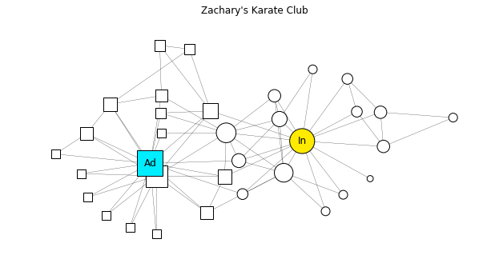

```python
karate = nx.karate_club_graph()
karate.nodes[8]['club'] = 'Officer' # the NetworkX method wrongly compiles this member's group
karate.graph['pos'] = dict((n,c[::-1]) for n,c in nx.kamada_kawai_layout(karate).items())
karate.graph['parts'] = nx.utils.groups(dict(karate.nodes(data='club')))
karate.graph['degs'] = nx.degree_centrality(karate)

print('Number of nodes: %d'%(karate.number_of_nodes()))
print('Number of edges: %d'%(karate.number_of_edges()))

plt.figure(figsize=(10,5))
plt.title('Zachary\'s Karate Club\n')
nx.draw(karate, pos=karate.graph['pos'], node_size=0, width=.25)
for i,part in enumerate(karate.graph['parts'].values()):
    nx.draw(karate, pos=karate.graph['pos'],
            width=0, edgecolors='k',
            node_size=[k*2000 if n in part else 0
                       for n,k in karate.graph['degs'].items()],
            node_color=[yellow]+['w']*32+[cyan],
            node_shape='s' if i else 'o',
            labels={33: 'Ad'} if i else {0: 'In'})
```

The third real network is the social network of a group of dolphins [4], in which an edge denotes two dolphins' frequent interaction. A group of biologists was recording 62 dolphins' behaviours in Doubtful Sound, New Zealand for some years, during which a dolphin (SN100, the purple triangle) suddenly left others. The biologists observed that the dolphins' community subsequently split into two (circles and squares).

You can download the dataset [here](http://www-personal.umich.edu/~mejn/netdata/dolphins.zip).

[output not shown]

```
Number of nodes: 62
Number of edges: 159
```

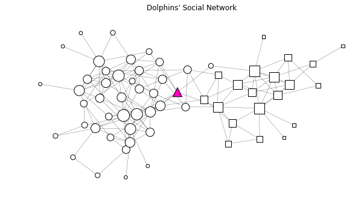

```python
dolphins = nx.read_gml('dolphins/dolphins.gml')
dolphins.graph['pos'] = dict((n,c[::-1]) for n,c in nx.kamada_kawai_layout(dolphins).items())
ref = ['Beescratch', 'DN16', 'DN21', 'DN63', 'Feather',
       'Gallatin', 'Jet', 'Knit', 'MN23', 'Mus',
       'Notch', 'Number1', 'Quasi', 'Ripplefluke', 'SN90',
       'TR82', 'Upbang', 'Wave', 'Web', 'Zig']
for n,d in dolphins.nodes(data=True):
    d['group'] = bool(n in ref)
dolphins.nodes['SN100']['group'] = None # whose left broke the community
dolphins.graph['parts'] = nx.utils.groups(dict(dolphins.nodes(data='group')))
dolphins.graph['degs'] = nx.degree_centrality(dolphins)

print('Number of nodes: %d'%(dolphins.number_of_nodes()))
print('Number of edges: %d'%(dolphins.number_of_edges()))

plt.figure(figsize=(10,5))
plt.title('Dolphins\' Social Network\n')
nx.draw(dolphins, pos=dolphins.graph['pos'], node_size=0, width=.25)
for i,part in dolphins.graph['parts'].items():
    nx.draw(dolphins, pos=dolphins.graph['pos'],
            width=0, edgecolors='k',
            node_size=[k*2000 if n in part else 0
                       for n,k in dolphins.graph['degs'].items()],
            node_color=magenta if i==None else 'w',
            node_shape='^' if i==None else ('s' if i else 'o'))
```

The fourth network is the collaboration network of over a thousand network scientists [5]. An edge connects two scientists who have at least coauthored once. While the original network is unconnected, I will only use its largest component, which comprises 379 network scientists.

You can download the dataset [here](http://www-personal.umich.edu/~mejn/netdata/netscience.zip).

```
Number of nodes: 379
Number of edges: 914
```

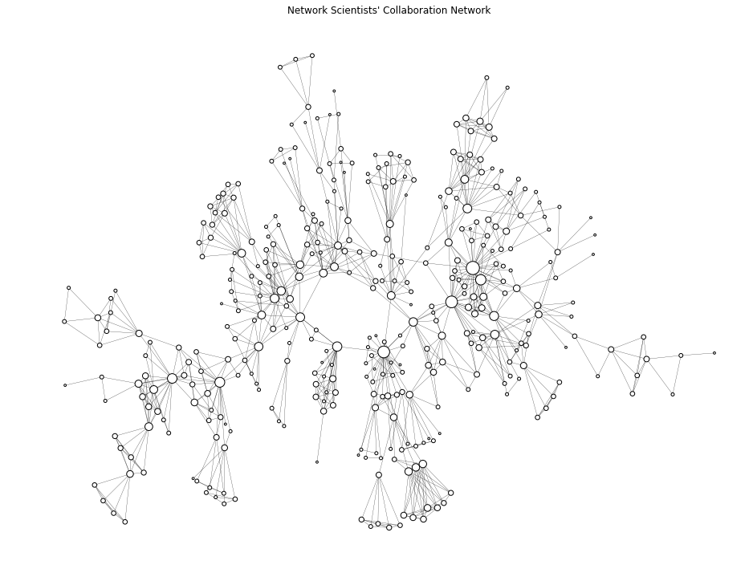

```python
netscience = nx.read_gml('netscience/netscience.gml')
largestComponent = sorted(list(max(nx.connected_components(netscience), key=len)))
netscience_ = nx.Graph()
netscience_.add_nodes_from(largestComponent)
for i in range(len(largestComponent)):
    for j in range(i):
        u,v = largestComponent[i],largestComponent[j]
        if netscience.has_edge(u,v):
            netscience_.add_edge(u,v)
netscience = netscience_.copy()
del netscience_

# you may use "netscience.subgraph(largestComponent)" instead
# but it shuffles the order of nodes undesirably

netscience.graph['pos'] = nx.kamada_kawai_layout(netscience)
netscience.graph['degs'] = nx.degree_centrality(netscience)

print('Number of nodes: %d'%(netscience.number_of_nodes()))
print('Number of edges: %d'%(netscience.number_of_edges()))

plt.figure(figsize=(16,12))
plt.title('Network Scientists\' Collaboration Network\n')
nx.draw(netscience, pos=netscience.graph['pos'],
        width=.25, edgecolors='k',
        node_size=[k*3000 for k in netscience.graph['degs'].values()],
        node_color='w')
```

# 1. Cut Size Minimization

We would often like to split a network into some partitions to reduce the edges connecting them as much as possible. Since removing the edges between partitions will break the network, the number of the edges is called the "cut size". The problem of cut size minimization particularly interests electronic engineers because they must divide a large circuit into several smaller and more manageable pieces for industrial manufacture.

## 1.1 The Kernighan-Lin algorithm

The canonical method to solve the problem is the Kernighan-Lin algorithm [6]. Given the size of partitions, the algorithm arbitrarily divides the network and

1. computes each node's gain, i.e. contribution to the cut size. Formally, a node's gain $G=E-I$ if it connects to $E$ nodes outside its partition and $I$ nodes inside.
2. The algorithm swaps the pair of nodes that reduces the cut size the most; swapping nodes $i$ and $j$ leads to a cut size change $\Delta_{ij}=G_i+G_j-2n_{ij}$, where $i$ and $j$ share $n_{ij}$ neighbours. If no pair reduces the cut size, the algorithm swaps the pair that increases the cut size the least.
3. After one swap, the algorithm freezes the swapped nodes so that they will not be swapped again.
4. The algorithm continues steps 1 to 3 until all nodes are swapped, and the procedure to swap all nodes once is called a pass.

The standard Kernighan-Lin algorithm goes through multiple passes until the cut size increases after a pass. The following block of code demonstrate one pass on Zachary's karate club.

```
Gain after one pass: -44
```

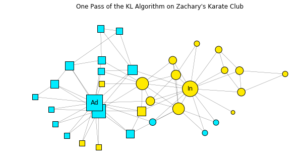

```python
free = list(karate)
part_size = karate.number_of_nodes()//2
bipart = [free[:part_size], free[part_size:]]
A = nx.to_numpy_array(karate)
A2 = A @ A

gain_pass = 0
while len(free) > 0:
    free_bipart = [sorted(list(set(free).intersection(bipart[b]))) for b in [0,1]]
    gain_indv = [np.array([A[n].sum() - 2*A[n, bipart[b]].sum()
                           for n in free_bipart[b]]) for b in [0,1]]
    gain_swap = np.broadcast_to(gain_indv[0].reshape(-1,1), map(len, gain_indv)) \
              + np.broadcast_to(gain_indv[1], map(len, gain_indv)) \
              - 2*A2[np.array(free_bipart[0]).reshape(-1,1), free_bipart[1]]

    gain_pass += gain_swap.min()
    coord = gain_swap.argmin()
    u = free_bipart[0][coord // len(gain_indv[0])]
    v = free_bipart[1][coord % len(gain_indv[1])]

    del free[free.index(u)], free[free.index(v)]
    bipart[0][bipart[0].index(u)] = v
    bipart[1][bipart[1].index(v)] = u
print('Gain after one pass: %d' % gain_pass)

for i,b in enumerate(bipart):
    for n in b:
        karate.nodes[n]['KL'] = i
b0 = karate.nodes[0]['KL']

plt.figure(figsize=(10,5))
plt.title('One Pass of the KL Algorithm on Zachary\'s Karate Club\n')
nx.draw(karate, pos=karate.graph['pos'], node_size=0, width=.25)
for i,part in enumerate(karate.graph['parts'].values()):
    nx.draw(karate, pos=karate.graph['pos'],
            width=0, edgecolors='k',
            node_size=[k*2000 if n in part else 0
                       for n,k in karate.graph['degs'].items()],
            node_color=[yellow if b==b0 else cyan for n,b in karate.nodes(data='KL')],
            node_shape='s' if i else 'o',
            labels={33:'Ad'} if i else {0:'In'})
```

Luckily, NetworkX has implemented the Kernighan-Lin algorithm for us. You can call it with community.kernighan_lin_bisection. The following block of code performs the Kernighan-LinL algorithm on the dolphins' social network. As you may see, communities in a large network rarely correspond to the partitions that have a small cut size.

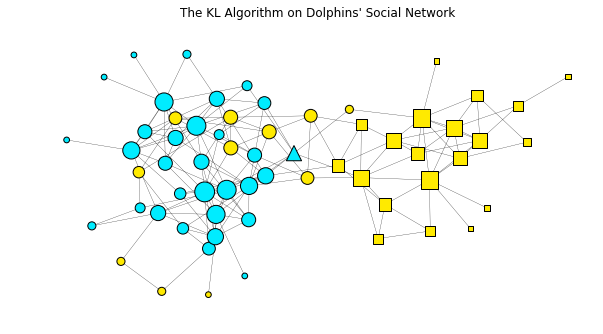

```python
for i,b in enumerate(nx.community.kernighan_lin_bisection(dolphins, seed=5056)):
    for n in b:
        dolphins.nodes[n]['KL'] = i

plt.figure(figsize=(10,5))
plt.title('The KL Algorithm on Dolphins\' Social Network\n')
nx.draw(dolphins, pos=dolphins.graph['pos'], node_size=0, width=.25)
for i,part in dolphins.graph['parts'].items():
    nx.draw(dolphins, pos=dolphins.graph['pos'],
            width=0, edgecolors='k',
            node_size=[k*2000 if n in part else 0
                       for n,k in dolphins.graph['degs'].items()],
            node_color= [cyan if b else yellow for n,b in dolphins.nodes(data='KL')],
            node_shape='^' if i==None else ('s' if i else 'o'))
```

## 1.2. Spectral partitioning

The problem of cut size minimization can be reformulated in terms of eigenvectors of a network's Laplacian matrix $\mathbf{L}$ [5]. Denote the $i$th smallest eigenvalue of $\mathbf{L}$ as $\lambda_i$ and the corresponding eigenvector $\mathbf{v}_i$. While $\lambda_1\equiv0$ and $\mathbf{v}_1\equiv\mathbf{1}$, signs of elements in $\mathbf{v}_2$ naturally divide the network into two partitions that helps reduce the cut size. (By the way, signs of elements in $\mathbf{v}_1\equiv\mathbf{1}$ trivially group all nodes into a single partition, which of course minimizes the cut size.)

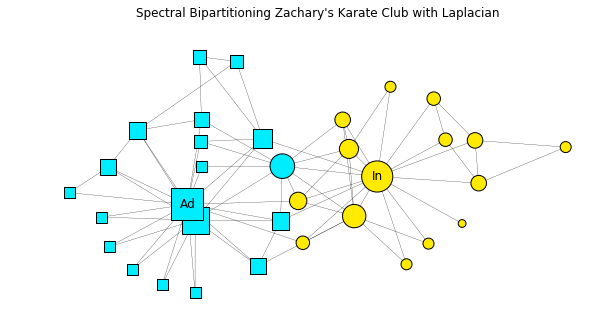

```python
for n,b in enumerate(np.linalg.eigh(nx.laplacian_matrix(karate).toarray())[1][:,1]):
    karate.nodes[n]['L'] = b>=0
b0 = karate.nodes[0]['L']

plt.figure(figsize=(10,5))
plt.title('Spectral Bipartitioning Zachary\'s Karate Club with Laplacian\n')
nx.draw(karate, pos=karate.graph['pos'], node_size=0, width=.25)
for i,part in enumerate(karate.graph['parts'].values()):
    nx.draw(karate, pos=karate.graph['pos'],
            width=0, edgecolors='k',
            node_size=[k*2000 if n in part else 0
                       for n,k in karate.graph['degs'].items()],
            node_color=[yellow if b==b0 else cyan for n,b in karate.nodes(data='L')],
            node_shape='s' if i else 'o',
            labels={33:'Ad'} if i else {0:'In'})
```

The magnitude of elements in $\mathbf{v}_2$ actually tell us the "strength" of the corresponding nodes. The larger magnitude $\left(\mathbf{v}_2\right)_i$ has, the more likely $i$ should stay at its partition. Hence, if sizes of the partitions are given, say $n$ versus $\left({N-n}\right)$, one should pack the $n$ nodes represented by the $n$ most positive (or negative) elements in $\mathbf{v}_2$ into the same partition and leave the others in the other partition. The following block of code colours each node according to the magnitudes of their corresponding elements in $\mathbf{v}_2$.

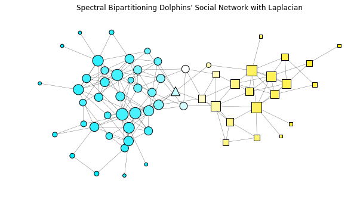

```python
ywc = mpl.colors.LinearSegmentedColormap.from_list('', [yellow, 'w', cyan])
cwy = mpl.colors.LinearSegmentedColormap.from_list('', [cyan, 'w', yellow])

vmin,vmax = 0,0
for n,b in enumerate(np.linalg.eigh(nx.laplacian_matrix(dolphins).toarray())[1][:,1]):
    dolphins.nodes[list(dolphins)[n]]['L'] = b
    if b < vmin: vmin = b
    elif b > vmax: vmax = b

plt.figure(figsize=(10,5))
plt.title('Spectral Bipartitioning Dolphins\' Social Network with Laplacian\n')
nx.draw(dolphins, pos=dolphins.graph['pos'], node_size=0, width=.25)
for i,part in dolphins.graph['parts'].items():
    nx.draw(dolphins, pos=dolphins.graph['pos'],
            width=0, edgecolors='k', cmap=ywc,
            node_size=[k*2000 if n in part else 0
                       for n,k in dolphins.graph['degs'].items()],
            node_color= [-b/vmin if b<0 else b/vmax
                         for n,b in dolphins.nodes(data='L')],
            node_shape='^' if i==None else ('s' if i else 'o'))
```

# 2. Hierarchical Clustering

By iteratively bipartitioning it, we can translate a network into a hierarchy of "intimacy", in which two nodes are closer to each other if they are more likely belong to the same partition. This approach is generally called "hierarchical clustering". To demonstrate this idea, I will use a small toy network shown below. Intuitively, nodes {0, 1, 2} should belong to the same partition, so should {3, 4, 5} and {6, 7, 8, 9}, but the case becomes ambiguous for node 10.

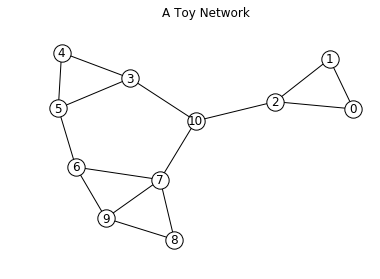

```python
toy = nx.disjoint_union_all([nx.cycle_graph(3), nx.cycle_graph(3),
                             nx.cycle_graph(4)])
toy.add_edges_from([(10,v) for v in [2,3,7]] + [(5,6), (7,9)])

plt.figure(figsize=(6,4))
plt.title('A Toy Network\n')
nx.draw_kamada_kawai(toy, node_color='w', edgecolors='k', with_labels=True)
```

There are two ways to build a hierarchy an agglomerative (bottom-up) approach and a divisive (top-down) approach. The former iteratively group nodes and partitions into larger partitions until all nodes belong to the same partition, whereas the latter iteratively divides the network and subsequent partitions into two until all nodes become an isolated partition.

While the Kernighan-Lin algorithm divides a graph according to cut size, the algorithms that I am going to cover employ other criteria.

## 2.1 The Ravasz algorithm

The Ravasz algorithm employs the agglomerative approach and builds a hierarchy according to similarity between partitions [7]. In short, starting from every node as an isolated partition, the Ravasz algorithm continuously groups the two most "similar" partitions into a larger one until all nodes become one single partition.

What does "similarity between partitions", though? This notion is defined upon "nodal similarity", which we have slightly gone through in Tutorial 2; we learnt to measure two nodes' similarity with Salton's cosine, Pearson correlation coefficient, and Euclidean distance then. If partitions $P$ and $Q$ repsectively have nodes $\left\{p_i\right\}$ and $\left\{q_j\right\}$, the similarity between the partitions $s{\left(P,Q\right)}$ may be defined in three ways:

1. simple clustering, i.e. $s{\left(P,Q\right)}=\min_{i,j} s{\left(p_i,q_j\right)}$,
2. complete clustering, i.e. $s{\left(P,Q\right)}=\max_{i,j} s{\left(p_i,q_j\right)}$, and
3. average clustering, i.e. $s{\left(P,Q\right)}=\langle{s{\left(p_i,q_j\right)}}\rangle$.

Here $s$ refers to the similarity measure that you are using. Ravasz et al.'s paper employs the so-called overlap coefficient $\omega$: for an adjacency matrix $\mathbf{A}$ and a degree vector $\mathbf{k}$,

\begin{align} \omega_{ij}=\dfrac{n_{ij}+A_{ij}} {\min{\left(k_i,k_j\right)}+1-A_{ij}}\,, \end{align}

where $i$ and $j$ share $n_{ij}$ neighbours. If the adjacency of $i$ contains or is contained by that of $j$, $\omega{\left(i,j\right)}=1$; if the two nodes are not connected and share no common neighbours, $\omega_{ij}=0$. (I prefer calling this metric "subset coefficient" instead.)

```python
def overlap_coefficient(G, u, v):
    a = int(G.has_edge(u, v))
    j = len(list(nx.common_neighbors(G, u, v))) + a
    ku, kv = G.degree(u), G.degree(v)
    return j/(min(ku,kv)+1-a)

def similarity(G, c1, c2, method=None, clustering=None):
    method = overlap_coefficient if method == None else method
    S = [[method(G, n1, n2) for n2 in c2] for n1 in c1]
    if clustering == 'single':
        return np.min(S)
    elif clustering == 'complete':
        return np.max(S)
    else:
        return np.mean(S)

def ravasz(G, method=None, clustering=None):
    N = G.number_of_nodes()
    tree = [{n} for n in G]
    while len(tree) > 1:
        yield tuple(tree)
        L = len(tree)
        S = -np.ones((L,L), float)
        for i in range(L):
            for j in range(i):
                S[i,j] = similarity(G, tree[i], tree[j], method, clustering)
        coord = S.argmax()
        i,j = coord%L,coord//L
        tree[i] = tree[i].union(tree[j])
        del tree[j]

toy.graph['ravasz'] = list(ravasz(toy))
print('The Ravasz algorithm on the toy network (average overlap coefficient):')
toy.graph['ravasz']
```

```
The Ravasz algorithm on the toy network (average overlap coefficient):
```

```
[({0}, {1}, {2}, {3}, {4}, {5}, {6}, {7}, {8}, {9}, {10}),
 ({0, 1}, {2}, {3}, {4}, {5}, {6}, {7}, {8}, {9}, {10}),
 ({0, 1, 2}, {3}, {4}, {5}, {6}, {7}, {8}, {9}, {10}),
 ({0, 1, 2}, {3, 4}, {5}, {6}, {7}, {8}, {9}, {10}),
 ({0, 1, 2}, {3, 4}, {5}, {6}, {7, 8}, {9}, {10}),
 ({0, 1, 2}, {3, 4}, {5}, {6}, {7, 8, 9}, {10}),
 ({0, 1, 2}, {3, 4, 5}, {6}, {7, 8, 9}, {10}),
 ({0, 1, 2}, {3, 4, 5}, {6, 7, 8, 9}, {10}),
 ({0, 1, 2, 10}, {3, 4, 5}, {6, 7, 8, 9}),
 ({0, 1, 2, 10}, {3, 4, 5, 6, 7, 8, 9})]
```

The Ravasz algorithm assigns node 10 in the toy network into the group of nodes {0, 1, 2}. However, as you may see, the performance of the algorithm highly depends on the input order of the nodes. For example, suppose nodes $s$, $t$, $u$, and $v$ are pairwise similar; at the level of bipartition, the algorithm probably returns $\left(\left\{s,t\right\},\left\{u,v\right\}\right)$ if I input $\left\{s,t,u,v\right\}$ but $\left(\left\{s,u\right\},\left\{t,v\right\}\right)$ if I input $\left\{s,u,t,v\right\}$.

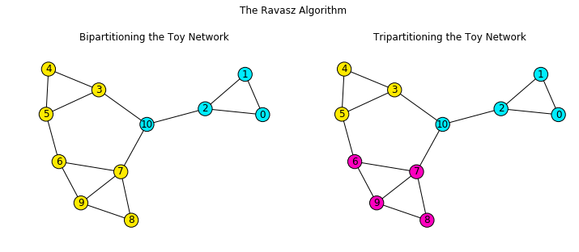

```python
plt.figure(figsize=(12,4))
plt.subplot(121)
plt.gcf().suptitle('The Ravasz Algorithm', y=1.1)
plt.title('Bipartitioning the Toy Network\n')
nx.draw_kamada_kawai(toy, edgecolors='k', with_labels=True,
                     node_color=[cyan if n in toy.graph['ravasz'][-1][0] else yellow for n in toy])
plt.subplot(122)
plt.title('Tripartitioning the Toy Network\n')
nx.draw_kamada_kawai(toy, edgecolors='k', with_labels=True,
                     node_color=[cyan if n in toy.graph['ravasz'][-2][0] else
                                (yellow if n in toy.graph['ravasz'][-2][1] else magenta)
                                 for n in toy])
```

A hierarchy can be clearly illustrated with a dendrogram, which is unfortunately hard to draw with Python. Here I demonstrate how to draw one with scipy.cluster.hierarchy.dendrogram. For an $N$-node network, the method takes in an $(N-1)\times4$ "linkage matrix" $\mathbf{Z}$. Each row of the matrix represents a join: at the $i$th join, nodes or partitions $Z_{i1}$ and $Z_{i2}$ group to form a $Z_{i4}$-element partition, and $Z_{i3}$ marks its height in the dendrogram. The following block of code sets each join's height the rank $r$ of its corresponding partition's size $s$, where $r=1\Leftrightarrow s=2$.

Please read the method's [documenation](https://docs.scipy.org/doc/scipy/reference/generated/scipy.cluster.hierarchy.dendrogram.html#scipy.cluster.hierarchy.dendrogram) for more information.

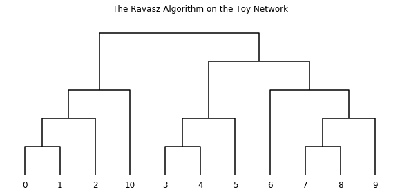

```python
from scipy.cluster import hierarchy

def to_linkage(tuples_of_sets, height='rank'):
    N = len(tuples_of_sets[0])
    Z = np.zeros((N-1,4), float)
    record = list(tuples_of_sets[0])

    for i in range(N-2):
        idxs,sets = [],[]
        for set_ in tuples_of_sets[i]:
            if set_ not in tuples_of_sets[i+1]:
                idxs.append(record.index(set_))
                sets.append(set_)
        record += [sets[0].union(sets[1])]
        Z[i,:2] = idxs
        Z[i,-1] = len(record[-1])
    Z[-1,:2] = [record.index(set_) for set_ in tuples_of_sets[-1]]
    Z[-1,-1] = N

    if height == 'rank':
        track = sorted(list(set(Z[:,3])))
        Z[:,2] = [track.index(Z[i,3])+1 for i in range(N-1)]
    else: # height == 'size'
        Z[:,2] = Z[:,3]-1
    return Z

plt.figure(figsize=(10,4))
plt.title('The Ravasz Algorithm on the Toy Network\n')
hierarchy.dendrogram(to_linkage(toy.graph['ravasz']),
                     color_threshold=0, above_threshold_color='k')
plt.gca().yaxis.set_visible(False)
for spine in plt.gca().spines.values():
    spine.set_visible(False)
```

You may actually implement the Ravasz algorithm with scipy.cluster.hierarchy.linkage, which is however, like other methods of SciPy, tough to control. The following dendrogram is produced with the SciPy-based Ravasz algorithm and qualitatively identical to the previous one despite the difference in the nodes' position.

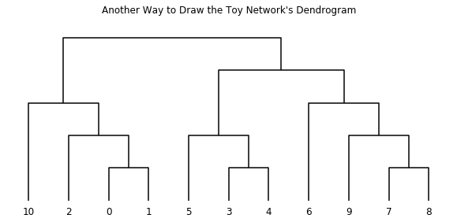

```python
# the Laplacian matrix is used instead of the adjacency matrix here
def overlap_distance(Li, Lj):
    i,j = np.argmax(Li>0), np.argmax(Lj>0)
    Ai,Aj = -Li,-Lj
    Ai[i],Aj[j] = 0,0
    c = np.sum(Ai*Aj)
    return 1-(c+Ai[j])/(min(Li[i],Lj[j])+1-Ai[j])

Z = hierarchy.linkage(nx.laplacian_matrix(toy).toarray(),
                      method='average', metric=overlap_distance)
track = sorted(list(set(Z[:,3])))
Z[:,2] = [track.index(Z[i,3])+1 for i in range(Z.shape[0])]

plt.figure(figsize=(10,4))
plt.title('Another Way to Draw the Toy Network\'s Dendrogram\n')
hierarchy.dendrogram(Z, color_threshold=0, above_threshold_color='k')
plt.gca().yaxis.set_visible(False)
for spine in plt.gca().spines.values():
    spine.set_visible(False)
```

Furthermore, you can generalize the Ravasz algorithm by setting parameters method and metric. Please check its [documentation](https://docs.scipy.org/doc/scipy/reference/generated/scipy.cluster.hierarchy.linkage.html#scipy.cluster.hierarchy.linkage) to see what values they can take. The following block of code grows the hierarchy according to the Jaccard coefficient $J$ between nodes and partitions:

\begin{align} J_{ij} = \dfrac{\lvert\mathbf{A}_i\cap\mathbf{A}_j\rvert} {\lvert\mathbf{A}_i\cup\mathbf{A}_j\rvert} = \dfrac{n_{ij}}{k_i+k_j-n_{ij}}\,, \end{align}

where $\mathbf{A}_i$ denotes $i$'s adjacency. The coefficient approaches $1$ if $i$ and $j$ share more common neighbours, otherwise it shrinks to $0$. The height of each join in the dendrogram below indicates the Jaccard distance $D_J=1-J$ between the two nodes or partitions that it connects.

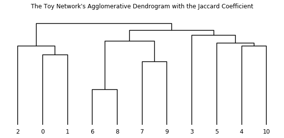

```python
Z = hierarchy.linkage(nx.to_numpy_array(toy), method='average', metric='jaccard')

plt.figure(figsize=(10,4))
plt.title('The Toy Network\'s Agglomerative Dendrogram with the Jaccard Coefficient\n')
hierarchy.dendrogram(Z, color_threshold=0, above_threshold_color='k')
plt.gca().yaxis.set_visible(False)
for spine in plt.gca().spines.values():
    spine.set_visible(False)
```

Lastly, I apply the Ravasz algorithm on the trade union, and the algorithm can tripartition the network into a group of Spanish speakers, a group of young English speakers, and a group of old English speakers.

By the way, avoid plotting a large network's dendrogram, which simply looks clumsy because of its numerous nodes.

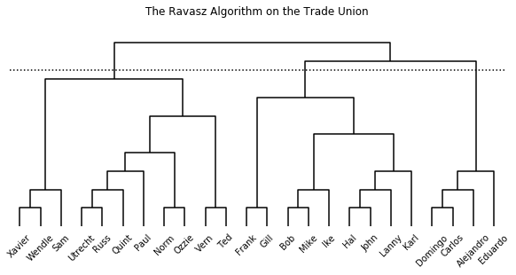

```python
strike.graph['ravasz'] = list(ravasz(strike))

plt.figure(figsize=(10,4))
plt.title('The Ravasz Algorithm on the Trade Union\n')
hierarchy.dendrogram(to_linkage(strike.graph['ravasz']), labels=list(strike),
                     color_threshold=0, above_threshold_color='k')
plt.axhline(8.5, c='k', ls=':')
plt.gca().yaxis.set_visible(False)
for spine in plt.gca().spines.values():
    spine.set_visible(False)
```

## 2.2 The Girvan-Newman algorithm

In contrast to the Ravasz algorithm, the Girvan-Newman algorithm employs the divisive approach and keeps dividing a network by successively deleting the most important edge [3]. Which edge is the most important in the network, though? Girvan and Newman considers the betweenness of nodes and generalizes it for edges: an important edge is traversed by many paths and thus have a high edge betweenness. Formally, the edge betweenness $b{\left(e\right)}$ of an edge $e$ reads, up to some normalization constant,

\begin{align} b{\left(e\right)} \sim \sum_{s<t}{\dfrac{g_{st}{\left(e\right)}} {g_{st}}}\,, \end{align}

where $g_{st}$ counts the shortest paths between nodes $s$ and $t$, and $g_{st}{\left(e\right)}$ similarly counts the ones that traverse $e$. Just like how the ordinary node betweenness may be extended to random walk betweenness, the mentioned edge betweenness may also be extended random walk edge betweenness $r{\left(e\right)}$: for $e=\left(u,v\right)$,

\begin{align} r{\left(e\right)} \sim \sum_{s<t} \lvert{\Gamma_{us}-\Gamma_{ut}-\Gamma_{vs}+\Gamma_{vt}}\rvert\,, \end{align}

where $\mathbf{\Gamma}=\left(\mathbf{D}-\mathbf{A}+\mathbf{1}\right)^{-1}$. The edge betweenness of edges is recalculated after deleting each edge.

You may call the Girvan-Newman algorithm with community.girvan_newman. The method by default uses the ordinary edge betweenness, but you may require it to use the random walk edge betweenness by setting most_valueable_edge accordingly.

```python
toy.graph['GN'] = list(nx.community.girvan_newman(toy))[::-1]

''' # alternatively
def random_walk_edge_betweenness(G):
    betweenness = {}
    for c in nx.connected_components(G):
        component = nx.subgraph(G,c)
        betweenness = {**betweenness,
                       **nx.edge_current_flow_betweenness_centrality(component,
                                                                     normalized=False)}
    return max(betweenness, key=betweenness.get)
toy.graph['GN'] = list(nx.community.girvan_newman(toy, most_valuable_edge=
                                                       random_walk_edge_betweenness))[::-1]
'''

toy.graph['GN']
```

```
[({0}, {1}, {2}, {3}, {4}, {5}, {6}, {7}, {8}, {9}, {10}),
 ({0}, {1}, {2}, {3}, {4}, {5}, {6}, {7}, {8, 9}, {10}),
 ({0}, {1}, {2}, {3}, {4}, {5}, {6}, {7, 8, 9}, {10}),
 ({0}, {1}, {2}, {3}, {4, 5}, {6}, {7, 8, 9}, {10}),
 ({0}, {1}, {2}, {3, 4, 5}, {6}, {7, 8, 9}, {10}),
 ({0}, {1, 2}, {3, 4, 5}, {6}, {7, 8, 9}, {10}),
 ({0, 1, 2}, {3, 4, 5}, {6}, {7, 8, 9}, {10}),
 ({0, 1, 2}, {3, 4, 5}, {6, 7, 8, 9}, {10}),
 ({0, 1, 2}, {3, 4, 5, 10}, {6, 7, 8, 9}),
 ({0, 1, 2}, {3, 4, 5, 6, 7, 8, 9, 10})]
```

While the Ravasz algorithm puts node 10 in the group of nodes {0, 1, 2}, the Girvan-Newman algorithm puts it in the group of nodes {3, 4, 5} as it tripartitions the toy network.

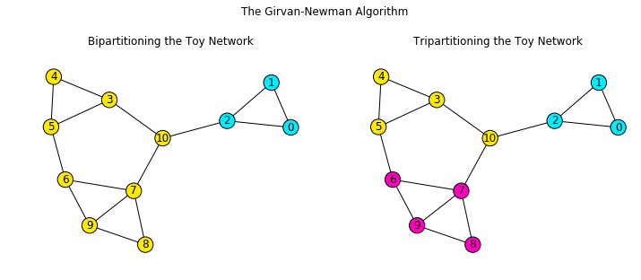

```python
plt.figure(figsize=(12,4))
plt.subplot(121)
plt.gcf().suptitle('The Girvan-Newman Algorithm', y=1.1)
plt.title('Bipartitioning the Toy Network\n')
nx.draw_kamada_kawai(toy, edgecolors='k', with_labels=True,
                     node_color=[cyan if n in toy.graph['GN'][-1][0] else yellow for n in toy])
plt.subplot(122)
plt.title('Tripartitioning the Toy Network\n')
nx.draw_kamada_kawai(toy, edgecolors='k', with_labels=True,
                     node_color=[cyan if n in toy.graph['GN'][-2][0] else
                                (yellow if n in toy.graph['GN'][-2][1] else magenta)
                                 for n in toy])
```

Again, you may plot a dendrogram to clearly visualize the hierarchy.

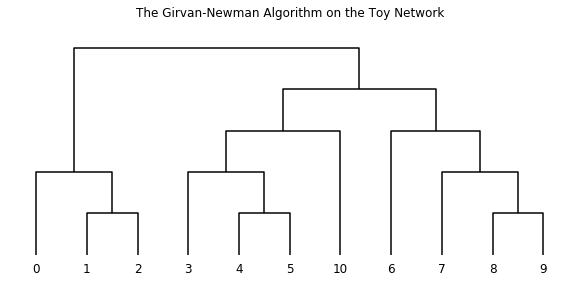

```python
plt.figure(figsize=(10,4))
plt.title('The Girvan-Newman Algorithm on the Toy Network\n')
hierarchy.dendrogram(to_linkage(toy.graph['GN']),
                     color_threshold=0, above_threshold_color='k')
plt.gca().yaxis.set_visible(False)
for spine in plt.gca().spines.values():
    spine.set_visible(False)
```

The Girvan-Newman algorithm is also able to divide the trade union into a group of Spanish speakers, a group of young English speakers, and a group of old English speakers.

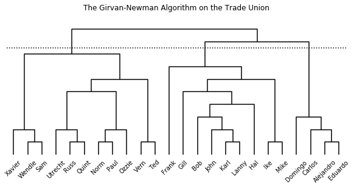

```python
strike.graph['GN'] = list(nx.community.girvan_newman(strike))[::-1]

plt.figure(figsize=(10,4))
plt.title('The Girvan-Newman Algorithm on the Trade Union\n')
hierarchy.dendrogram(to_linkage(strike.graph['GN']), labels=list(strike),
                     color_threshold=0, above_threshold_color='k')
plt.axhline(8.5, c='k', ls=':')
plt.gca().yaxis.set_visible(False)
for spine in plt.gca().spines.values():
    spine.set_visible(False)
```

Finally, let us see how the Girvan-Newman algorithm perform on bipartitioning Zachary's karate club: only one node is misclassified. This impressive result helped spark researches on algorithms of community detection.

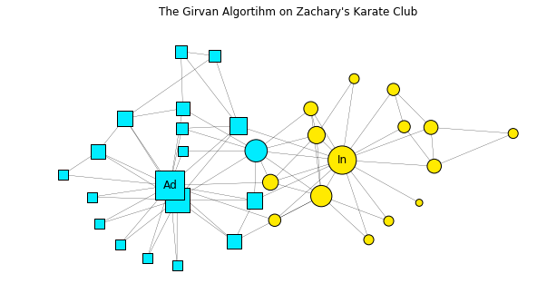

```python
karate_GN = next(nx.community.girvan_newman(karate))[0]
for n in range(karate.number_of_nodes()):
    karate.nodes[n]['GN'] = n in karate_GN
b0 = karate.nodes[0]['GN']

plt.figure(figsize=(10,5))
plt.title('The Girvan Algortihm on Zachary\'s Karate Club\n')
nx.draw(karate, pos=karate.graph['pos'], node_size=0, width=.25)
for i,part in enumerate(karate.graph['parts'].values()):
    nx.draw(karate, pos=karate.graph['pos'],
            width=0, edgecolors='k',
            node_size=[k*2000 if n in part else 0
                       for n,k in karate.graph['degs'].items()],
            node_color=[yellow if b==b0 else cyan for n,b in karate.nodes(data='GN')],
            node_shape='s' if i else 'o',
            labels={33:'Ad'} if i else {0:'In'})
```

# 3. From Partitions to Communities

So far we have only focused on graph partitioning, for which we are given the number of partitions and sometimes also their size. This is therefore fundamentally different from community detection because in this case we rarely know the number of communities and their size in advance. The problem of community detection also inevitably raises a philosophical question: what is a "community"?

```python
# the gift-wrapping algorithm; for visualizing communities
def gift_wrap(pts):
    convexHull = []
    ptOnHull = pts[pts[:,0].argmin(), :] # leftmost
    counter_clock = lambda a,b,c: (c[1]-a[1])*(b[0]-a[0]) \
                               >= (b[1]-a[1])*(c[0]-a[0]) # cross product
    while True:
        convexHull.append(ptOnHull)
        endpt = pts[0]
        for j in range(1, len(pts)):
            if np.allclose(endpt, ptOnHull) or \
            not counter_clock(pts[j], convexHull[-1], endpt):
                # pts[j] on the left of (convexHull[-1], endpt)
                endpt = pts[j]
        ptOnHull = endpt
        if np.allclose(endpt, convexHull[0]):
            return np.array(convexHull)
```

## 3.1 Defining communities

There is no universal definition of "community" upon which everyone agrees. Still, we intuitively think that a community should be a dense subgraph and that a node link to nodes within the same community more frequently than to ones outside. Such intuitions lead to various plausible topological definitions of communities.

In the following sections, $Q$ represents some community that contains nodes $\left\{n\right\}$ and has a characteristic number $k$. A node's characteristic number $q$ is subsequently defined as the maximal $k$ of all communities to which it belongs; conversely, communities with $k=q$ are the node's maximal communities. A community is commutative if and only if every node inside has the same $q$.

### Clique.

A node's clique-based communities are the cliques to which it belongs.

A $k$-clique is a $k$-node subgraph in which every node links to all the other $\left(k-1\right)$ nodes.

This definition of community is however too restrictive. There are few large cliques in real networks but mostly $2$- and $3$-cliques, i.e. trivial edges and triangles. Furthermore, it is NP-complete to find cliques in a network, meaning that the running time rises exponentially with the network's size.

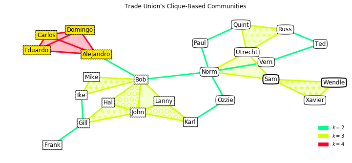

```python
def clique_community(G, commutative=False):
    Qs = {tuple(Q) for Qs in nx.cliques_containing_node(G).values() for Q in Qs}
    if commutative:
        Qs = {Q for Q in Qs if all(nx.node_clique_number(G, n) == len(Q) for n in Q)}
    return nx.utils.groups(dict((Q, len(Q)) for Q in Qs))
strike.graph['clique'] = clique_community(strike, False)
kMax = max(strike.graph['clique'])

plt.figure(figsize=(12,5))
plt.title('Trade Union\'s Clique-Based Communities\n')
for k in range(min(strike.graph['clique']), kMax+1):
    plt.fill([0], [0], c=cmap(k/kMax), label='$k=%d$'%k)
    plt.legend(frameon=False, loc=4)

for k in sorted(strike.graph['clique']):
    for i,Q in enumerate(strike.graph['clique'][k]):
        pts = np.array(list(strike.graph['pos'][n] for n in Q))
        xy = gift_wrap(pts).T
        plt.fill(*xy, c=cmap(k/kMax), alpha=.25*k/kMax)
        plt.fill(*xy, fc='none', ec=cmap(k/kMax), lw=0,
                 alpha=.5, hatch=['','o','O','*'][i%4])
        idxs = dict((n, idx) for idx,n in enumerate(Q))
        for (u,v) in nx.subgraph(strike, Q).edges:
            plt.plot(*pts[[idxs[u],idxs[v]]].T, '-', c=cmap(k/kMax), lw=3)

nx.draw(strike, pos=strike.graph['pos'], node_size=0, width=.25)
for bbox,N in nx.utils.groups(dict(strike.nodes(data='bbox'))).items():
    labels = dict((n,n) for n in N)
    nx.draw(strike, pos=strike.graph['pos'],
            node_size=0, width=0, labels=labels,
            bbox=dict(fc=bbox[0], boxstyle=bbox[1], lw=bbox[2]))
```

### Component.

A node's component-based communities are the components to which it belongs.

A $k$-component is a subgraph that remains connected before removing $k$ nodes.

In other words, a $k$-component definitely does not break even after removing $\left(k-1\right)$ nodes. The value $k$ is called the component's connectivity.

The $1$-component of a connected graph trivially contains all nodes, and $2$- and $3$-components are commonly referred to as bicomponents and tricomponents. The nodes whose removal breaks a component forms its node cut-set. If a node cut-set only has one node, the only node is called a broker.

```
Brokers in the trade union: Bob, Sam, Norm, Alejandro, Gill
```

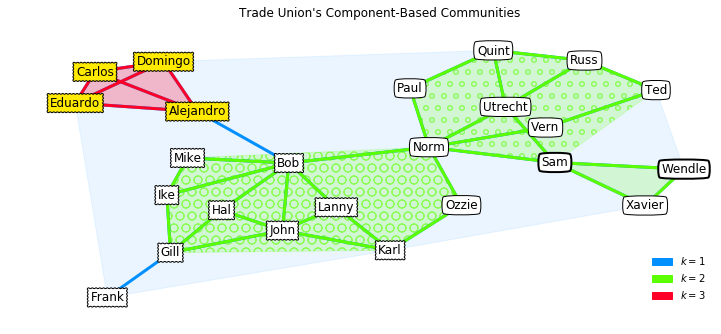

```python
def component_community(G, commutative=False):
    Qd = nx.k_components(G) # {k: [{Q}]}
    qs = dict((n, max([k for k in Qd for Q in Qd[k] if n in Q])) for n in G)
    Qs = {tuple(Q) for Qs in Qd.values() for Q in Qs}
    if commutative:
        Qs = {Q for Q in Qs if all(qs[n]==nx.node_connectivity(nx.subgraph(G, Q)) for n in Q)}
    return nx.utils.groups(dict((Q, nx.node_connectivity(nx.subgraph(G, Q))) for Q in Qs))
strike.graph['component'] = component_community(strike, False)
kMax = max(strike.graph['component'])

plt.figure(figsize=(12,5))
plt.title('Trade Union\'s Component-Based Communities\n')
for k in range(min(strike.graph['component']), kMax+1):
    plt.fill([0], [0], c=cmap(k/kMax), label='$k=%d$'%k)
    plt.legend(frameon=False, loc=4)

for k in sorted(strike.graph['component']):
    for i,Q in enumerate(strike.graph['component'][k]):
        pts = np.array(list(strike.graph['pos'][n] for n in Q))
        xy = gift_wrap(pts).T
        plt.fill(*xy, c=cmap(k/kMax), alpha=.25*k/kMax)
        plt.fill(*xy, fc='none', ec=cmap(k/kMax), lw=0,
                 alpha=.5, hatch=['','o','O','*'][i%4])
        idxs = dict((n, idx) for idx,n in enumerate(Q))
        for (u,v) in nx.subgraph(strike, Q).edges:
            plt.plot(*pts[[idxs[u],idxs[v]]].T, '-', c=cmap(k/kMax), lw=3)

nx.draw(strike, pos=strike.graph['pos'], node_size=0, width=.25)
for bbox,N in nx.utils.groups(dict(strike.nodes(data='bbox'))).items():
    labels = dict((n,n) for n in N)
    nx.draw(strike, pos=strike.graph['pos'],
            node_size=0, width=0, labels=labels,
            bbox=dict(fc=bbox[0], boxstyle=bbox[1], lw=bbox[2]))

print('Brokers in the trade union: ', end='')
print(', '.join([list(b)[0] for b in nx.all_node_cuts(strike, 1)]), end='\n\n')
```

### Edge subgraph.

A node's edge-subgraph-based communities are the edge subgraphs to which it belongs.

A $k$-edge-subgraph is a subgraph that remains connected before removing $k$ edges.

The value $k$ is called the subgraph's edge connectivity. (On the other hand, a $k$-edge-component cotains nodes with pairwise edge connectivity $k$ on the original graph, meaning that every node in the edge component can reach any other node via at least $k$ edge-disjoint paths on the orignal graph. While a $k$-edge-subgraph is always a $k$-edge-component, the converse generally fails for $k>2$.)

The $1$-edge-subgraph of a connected graph trivially contains all nodes. The edges whose removal breaks an edge subgraph forms its edge cut-set. If an edge cut-set only has one edge, the only edge is called a bridge.

```
Bridges in the trade union: ('Frank', 'Gill'), ('Alejandro', 'Bob')
```

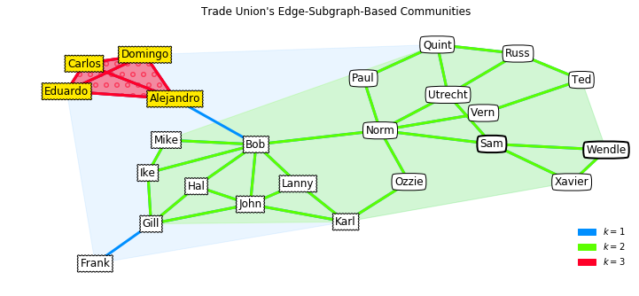

```python
def edge_subgraph_community(G, commutative=True):
    Qd = {}
    for k in range(1, len(G)):
        Qd[k] = [Q for Q in nx.k_edge_subgraphs(G, k) if len(Q)>1]
        if len(Qd[k]) == 0:
            del Qd[k]
            break
    qs = dict((n, max([k for k in Qd for Q in Qd[k] if n in Q])) for n in G)
    Qs = {tuple(Q) for Qs in Qd.values() for Q in Qs}
    if commutative:
        Qs = {Q for Q in Qs if all(qs[n]==nx.edge_connectivity(nx.subgraph(G, Q)) for n in Q)}
    return nx.utils.groups(dict((Q, nx.edge_connectivity(nx.subgraph(G, Q))) for Q in Qs))
strike.graph['edge_subgraph'] = edge_subgraph_community(strike, False)
kMax = max(strike.graph['edge_subgraph'])

plt.figure(figsize=(12,5))
plt.title('Trade Union\'s Edge-Subgraph-Based Communities\n')
for k in range(min(strike.graph['edge_subgraph']), kMax+1):
    plt.fill([0], [0], c=cmap(k/kMax), label='$k=%d$'%k)
    plt.legend(frameon=False, loc=4)

for k in sorted(strike.graph['edge_subgraph']):
    for i,Q in enumerate(strike.graph['edge_subgraph'][k]):
        pts = np.array(list(strike.graph['pos'][n] for n in Q))
        xy = gift_wrap(pts).T
        plt.fill(*xy, c=cmap(k/kMax), alpha=.25*k/kMax)
        plt.fill(*xy, fc='none', ec=cmap(k/kMax), lw=0,
                 alpha=.5, hatch=['','o','O','*'][i%4])
        idxs = dict((n, idx) for idx,n in enumerate(Q))
        for (u,v) in nx.subgraph(strike, Q).edges:
            plt.plot(*pts[[idxs[u],idxs[v]]].T, '-', c=cmap(k/kMax), lw=3)

nx.draw(strike, pos=strike.graph['pos'], node_size=0, width=.25)
for bbox,N in nx.utils.groups(dict(strike.nodes(data='bbox'))).items():
    labels = dict((n,n) for n in N)
    nx.draw(strike, pos=strike.graph['pos'],
            node_size=0, width=0, labels=labels,
            bbox=dict(fc=bbox[0], boxstyle=bbox[1], lw=bbox[2]))

print('Bridges in the trade union: ', end='')
print(', '.join([str(b) for b in nx.bridges(strike)]), end='\n\n')
```

### Core.

A node's core-based communities are the cores to which it belongs.

A $k$-core is a subgraph in which every node links to $k$ other nodes.

The value $k$ is called the core's coreness.

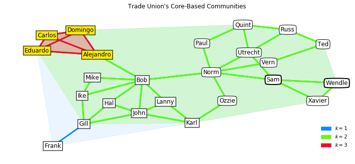

```python
def core_community(G, commutative=True):
    qs = nx.core_number(G)
    Qs = {tuple(nx.k_core(G, k)) for k in range(min(qs.values()),
                                                max(qs.values())+1)}
    if commutative:
        Qs = {Q for Q in Qs if all(qs[n]==qs[Q[0]] for n in Q)}
    return dict((min(nx.core_number(nx.subgraph(G, Q)).values()), {Q}) for Q in Qs)
strike.graph['core'] = core_community(strike, False)
kMax = max(strike.graph['core'])

plt.figure(figsize=(12,5))
plt.title('Trade Union\'s Core-Based Communities\n')
for k in range(min(strike.graph['core']), kMax+1):
    plt.fill([0], [0], c=cmap(k/kMax), label='$k=%d$'%k)
    plt.legend(frameon=False, loc=4)

for k in sorted(strike.graph['core']):
    for i,Q in enumerate(strike.graph['core'][k]):
        pts = np.array(list(strike.graph['pos'][n] for n in Q))
        xy = gift_wrap(pts).T
        plt.fill(*xy, c=cmap(k/kMax), alpha=.25*k/kMax)
        plt.fill(*xy, fc='none', ec=cmap(k/kMax), lw=0,
                 alpha=.5, hatch=['','o','O','*'][i%4])
        idxs = dict((n, idx) for idx,n in enumerate(Q))
        for (u,v) in nx.subgraph(strike, Q).edges:
            plt.plot(*pts[[idxs[u],idxs[v]]].T, '-', c=cmap(k/kMax), lw=3)

nx.draw(strike, pos=strike.graph['pos'], node_size=0, width=.25)
for bbox,N in nx.utils.groups(dict(strike.nodes(data='bbox'))).items():
    labels = dict((n,n) for n in N)
    nx.draw(strike, pos=strike.graph['pos'],
            node_size=0, width=0, labels=labels,
            bbox=dict(fc=bbox[0], boxstyle=bbox[1], lw=bbox[2]))
```

## 3.2 Assessing communities

We have gone through multiple ways to obtain a potential community, i.e. a group of nodes that we think it is a community. Our potential communities look drasticially different based on the concepts we are relying on, e.g. the Kernighan-Lin algorithm, the Girvan-Newman algorithm, or the $k$-component. How can we assess these potential communities? After all, do they really represent communities?

### Strong and weak communities.

A node's degree $k$ can be divided into an interior degree $k^\text{int}$, which counts the links between it and nodes from the same community, and an exterior one $k^\text{ext}=k-k^\text{int}$, which counts the links between it and nodes from other communities. A strong community satisfies $k^\text{int} > k^\text{ext}$ for all nodes, whereas a weak community satisfies a weaker condition: $\sum_i {k_i^\text{int}} > \sum_i {k_i^\text{ext}}$. A strong community obviously satisfies the weak community's condition at the same time. We may then define a community's power $p\in\left[0,1\right]$ as

\begin{align} p = \begin{cases} 1-\min\left({\langle{\dfrac{k^\text{ext}} {k^\text{int}}}\rangle, 1}\right) & \left(\text{strong}\right) \\ 1-\min\left({\dfrac{\sum_n{k_n^\text{ext}}} {\sum_n{k_n^\text{int}}}, 1}\right) & \left(\text{weak}\right) \end{cases}\,, \end{align}

which tells us how likely it indeed represents a strong or weak community. If a potential community does not satisfy the strong or weak condition, its corresponding power drops to $p=0$. This definition however favours a large community; particularly, a community has $p\equiv1$ if it contains all nodes since $k^\text{ext}=0$. A better quantity hence normalizes the power with the size of the community $n$ and that of the network $N$, i.e.

\begin{align} \hat{p} = \begin{cases} 1-\min\left({\dfrac{n}{N-n} \langle{\dfrac{k^\text{ext}} {k^\text{int}}}\rangle, 1}\right) & \left(\text{strong}\right) \\ 1-\min\left({\dfrac{n}{N-n} \dfrac{\sum_n{k_n^\text{ext}}} {\sum_n{k_n^\text{int}}}, 1}\right) & \left(\text{weak}\right) \end{cases}\,. \end{align}

Note that the normalization fails for $n=N$ because it yields $\dfrac{0}{0}$.

```python
def power(G, nbunch, strong=True, normalize=True):
    N, n = len(G), len(nbunch)
    if n == N: return np.nan
    if n == 1: return 0
    f = n/(N-n) if normalize else 1

    kInt = lambda n: nx.subgraph(G, nbunch).degree[n]
    kExt = lambda n: G.degree[n] - kInt(n)
    kInts = np.array([kInt(n) for n in nbunch])
    kExts = np.array([kExt(n) for n in nbunch])

    if strong:
        if 0 in kInts: return 0
        return 1 - min(np.mean(kExts/kInts)*f, 1)
    else:
        if kInts.sum() == 0: return 0
        return 1 - min(kExts.sum()/kInts.sum()*f, 1)

power(strike, ['Alejandro', 'Carlos', 'Domingo', 'Eduardo'])
```

```
0.9833333333333333
```

```
The 3-partition yields the highest average strong power:
1. {'Xavier', 'Ozzie', 'Paul', 'Wendle', 'Ted', 'Vern', 'Russ', 'Utrecht', 'Sam', 'Norm', 'Quint'},
2. {'Ike', 'Bob', 'Gill', 'Hal', 'Mike', 'John', 'Frank', 'Karl', 'Lanny'}, and
3. {'Eduardo', 'Alejandro', 'Carlos', 'Domingo'}.
```

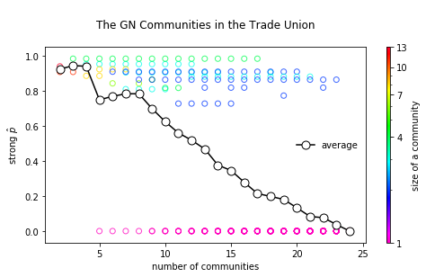

```python
commNumRange = np.arange(2, strike.number_of_nodes()+1)
sizeMax = max(map(len, strike.graph['GN'][-1]))
sizeRange = np.arange(1, sizeMax+1, 3)
avgPowers = []

plt.figure(figsize=(8,4))
for c in commNumRange:
    Qs = strike.graph['GN'][-c+1]
    colors = [cmap((np.log(len(Q)))/(np.log(sizeMax))) for Q in Qs]
    ps = [power(strike, Q, True) for Q in Qs]
    plt.scatter([c]*c, ps, facecolors='none', edgecolors=colors, alpha=.75)
    avgPowers.append(sum(ps)/c)
plt.plot(commNumRange, avgPowers, 'ko-', mfc='white', ms=9, label='average')
plt.legend(frameon=False, loc=5)

norm = mpl.colors.LogNorm(1, sizeMax)
smap = mpl.cm.ScalarMappable(norm=norm, cmap=cmap)
smap.set_array([])
cbar = plt.colorbar(smap, aspect=50, ticks=sizeRange,
                    label='size of a community')
cbar.set_ticklabels(sizeRange)

plt.xlabel('number of communities')
plt.ylabel('strong $\hat{p}$')
plt.title('\nThe GN Communities in the Trade Union\n')

opt = commNumRange[avgPowers.index(max(avgPowers))]
print('The %d-partition yields the highest average strong power:' % opt)
for c,Q in enumerate(strike.graph['GN'][-opt+1]):
    print('%d.'%(c+1), Q, end='.' if c+1==opt else \
                       (', and\n' if c+2==opt else ', \n'))
```

### Modularity.

Now we come to the most important concept of this tutorial: **modularity** $M\in\left[-1,1\right]$. As introduced in Tutorial 4,

\begin{align} B_{ij} &= A_{ij}-\dfrac{k_ik_j}{2E} \\ M{(\mathbf{Q})} &= \dfrac{1}{2E} \sum_{i,j} {B_{ij}\,\delta{\left(Q_i,Q_j\right)}} = \dfrac{1}{2E} \sum_{(i,j)\in Q} {B_{ij}}\,, \end{align}

where node $i$ belongs to the potential community $Q_i$ in an $E$-edge network. In terms of matrix,

\begin{align} M{(\mathbf{\Delta})} = \dfrac{1}{2E}\mathrm{tr}{\left({\mathbf{\Delta^\top B\Delta}}\right)}\,, \end{align}

where the index matrix $\mathbf{\Delta}$ contains $\Delta_{is}=1$ if $i$ belongs to the $s$th community, i.e. $Q_i=s$, and $0$ otherwise. You can compute the modularity matrix $\mathbf{B}$ with modularity_matrix. The definition can be alternatively reformulated as

\begin{align} M{(\mathbf{Q})} = \sum_Q {\left[\dfrac{E_Q}{E} -\left(\dfrac{K_Q}{2E}\right)^2 \right]}\,, \end{align}

where each potential community $Q$ contains $E_Q$ edges and some nodes with a **total** degree $K_Q$ on the **original** network [8]. The summand is also referred to as a single community $Q$'s modularity $M_Q$. From this reformulation, we see two special cases:

1. If all nodes are grouped as a single community, $K_Q=2E$ and $E_Q=E$ leads to $M=0$.
2. If every node is classified as a separate community, $E_Q\equiv0$ leads to $M<0$.

```python
def modularity(G, communities, matrix=False):
    E = G.number_of_edges()
    Qs = communities
    if matrix:
        B = nx.modularity_matrix(G)
        D = np.array([[1 if i in Q else 0 for Q in Qs] for i in G])
        return np.trace(D.T@B@D)/(2*E)
    else:
        M = 0
        for Q in Qs:
            H = nx.subgraph(G, Q)
            EQ = H.number_of_edges()
            KQ = sum(G.degree[n] for n in H)
            M += EQ/E-(KQ/(2*E))**2
        return M

def modularity_single(G, community):
    E = G.number_of_edges()
    H = nx.subgraph(G, community)
    EQ = H.number_of_edges()
    KQ = sum(G.degree[n] for n in H)
    return EQ/E-(KQ/(2*E))**2

(modularity_single(strike, strike.graph['GN'][-1][0]),
 modularity_single(strike, strike.graph['GN'][-1][1]))
```

```
(0.2174515235457064, 0.2174515235457064)
```

Modularity helps measure how well an $c$-partition represents $c$ communities. Precisely speaking, a $c$-partition $\mathbf{Q}$ better represents $c$ communities as $M{\left(\mathbf{Q}\right)}$ approaches $1$. This effectiveness of modularity relies on the fundamental hypothesis for community detection:

a random network lacks communities.

On an $E$-edge network, there are $2E$ stubs, i.e. termini of edges. If the network is random and permits multiple edges and self loops, a stub of node $i$ may link to a stub of node $j$ with a probability $\dfrac{k_j}{2E-1}$. Since $i$ has $k_i$ stubs, the expected number of edges between $i$ and $j$ reads $\dfrac{k_ik_j}{2E-1}\approx\dfrac{k_ik_j}{2E}$. In other words, if a network is randomly wired, $\dfrac{k_ik_j}{2E}$ amounts to the probability of the existence of an edge $\left(i,j\right)$.

Therefore if $M>0$, nodes classfied in the same potential community has more edges than that expected by chance, meaning that they form a denser subgraph than the one they would form on a random network. While we believe that a community is a dense subgraph, the fundamental hypothesis sets a random network as the reference point of density and thus community: since the subgraph is denser than its random counterpart, it is more likely for the subgraph to represent a real community than not to represent any. In general, a greater $M{\left(\mathbf{Q}\right)}$ implies that $\mathbf{Q}$ identifies the real communities more reliably.

```
The 4-partition yields the highest modularity:
1. {'Xavier', 'Sam', 'Wendle'},
2. {'Ozzie', 'Paul', 'Ted', 'Vern', 'Russ', 'Utrecht', 'Norm', 'Quint'},
3. {'Ike', 'Bob', 'Gill', 'Hal', 'Mike', 'John', 'Frank', 'Karl', 'Lanny'}, and
4. {'Eduardo', 'Alejandro', 'Carlos', 'Domingo'}.
```

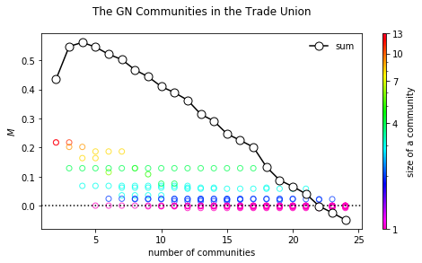

```python
modularities = []
plt.figure(figsize=(8,4))
plt.axhline(0, c='k', ls=':')
for c in commNumRange:
    Qs = strike.graph['GN'][-c+1]
    colors = [cmap((np.log(len(Q)))/(np.log(sizeMax))) for Q in Qs]
    Ms = [modularity_single(strike, Q) for Q in Qs]
    plt.scatter([c]*c, Ms, facecolors='none', edgecolors=colors, alpha=.75)
    modularities.append(sum(Ms))

''' # alternatively
modularities = [modularity(strike, Qs) for Qs in strike.graph['GN'][::-1]]
'''

plt.plot(commNumRange, modularities, 'ko-', mfc='white', ms=9, label='sum')
plt.legend(frameon=False, loc=1)
cbar = plt.colorbar(smap, aspect=50, ticks=sizeRange,
                    label='size of a community')
cbar.set_ticklabels(sizeRange)

plt.xlabel('number of communities')
plt.ylabel('$M$')
plt.title('The GN Communities in the Trade Union\n')

opt = commNumRange[modularities.index(max(modularities))]
print('The %d-partition yields the highest modularity:' % opt)
for c,Q in enumerate(strike.graph['GN'][-opt+1]):
    print('%d.'%(c+1), Q, end='.' if c+1==opt else \
                       (', and\n' if c+2==opt else ', \n'))
```

# 4. Modularity Maximization

Although there is no agreement upon the definition of a community, network scientists commonly agree that modularity well assesses a potential community. Given its importance, various algorithms are devoted to maximize it.

## 4.1 Spectral partitioning

We can maximize a bipartition's modularity by inspecting the eigenvector $\mathbf{v}_N$ associated with the largest eigenvalue $\beta_N$ of a network's modularity matrix $\mathbf{B}$ [5]. If $\mathrm{sign}{\left[\left(\mathbf{v}_N\right)_i\right]}=\mathrm{sign}{\left[\left(\mathbf{v}_N\right)_j\right]}$, nodes $i$ and $j$ belong to the same partition. The magnitude $\lvert{\left({\mathbf{v}_N}\right)_i}\rvert$, as same as the case for a Laplacian matrix's spectrum, indicates how strongly node $i$ is affiliated to its partition.

In fact, after some matrix analysis, the spectral method can be generalized to maximize the modularity of a $k$-partition with an arbitrary $k$. Read Newman's derivation if you are interested [5].

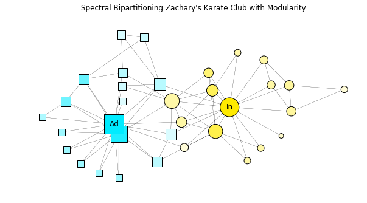

```python
vmin,vmax = 0,0
for n,b in enumerate(np.linalg.eigh(np.asarray(nx.modularity_matrix(karate)))[1][:,-1]):
    karate.nodes[list(karate)[n]]['B'] = b
    if b < vmin: vmin = b
    elif b > vmax: vmax = b

plt.figure(figsize=(10,5))
plt.title('Spectral Bipartitioning Zachary\'s Karate Club with Modularity\n')
nx.draw(karate, pos=karate.graph['pos'], node_size=0, width=.25)
for i,part in enumerate(karate.graph['parts'].values()):
    nx.draw(karate, pos=karate.graph['pos'],
            width=0, edgecolors='k', cmap=cwy,
            node_size=[k*2000 if n in part else 0
                       for n,k in karate.graph['degs'].items()],
            node_color= [-b/vmin if b<0 else b/vmax
                         for n,b in karate.nodes(data='B')],
            node_shape='s' if i else 'o',
            labels={33:'Ad'} if i else {0:'In'})
```

## 4.2 The Newman algorithm

Starting with every node as an individual community, the Newman algorithm iteratively joins the pair of connected communities that can increase modularity $M$ the most [9]. The $k$-parition with the highest $M{\left(k\right)}$ is deemed the optimal parition. The following block of code impelements the algorithm. (My implementation is inefficient, though.)

```python
def newman(G):
    hierarchy = [[[n] for n in G]] # [Qs] = [[Q]] = [[[nodes]]]
    Ms = [modularity(G, hierarchy[-1])]
    idx_by_node = dict((n, i) for i,n in enumerate(G))
    Q_by_idx = dict((idx, list(Q)) for idx, Q in nx.utils.groups(idx_by_node).items())

    for i in range(G.number_of_nodes()-2):
        Ms.append(-1)
        checked_pairs = []
        for u, v in G.edges:
            a, b = idx_by_node[u], idx_by_node[v]
            if a != b and {a, b} not in checked_pairs:
                checked_pairs.append({a, b})
                Qs_trial = [Q_by_idx[a] + Q_by_idx[b]] \
                         + [Q_by_idx[c] for c in Q_by_idx if c not in [a, b]]
                M = modularity(G, Qs_trial)
                if M > Ms[-1]:
                    Ms[-1] = M
                    a_propose, b_propose = a, b
                    Qs_propose = Qs_trial
        hierarchy.append(Qs_propose)
        min_, max_ = min(a_propose, b_propose), max(a_propose, b_propose)
        Q_by_idx[min_] = [n for n in Q_by_idx[min_]] \
                       + [n for n in Q_by_idx[max_]]
        # I tried 'extend' but it led to some bugs that I could not solve
        # so I resorted to this clumsy way of assignment
        for n in Q_by_idx[max_]:
            idx_by_node[n] = min_
        del Q_by_idx[max_]
    return hierarchy[Ms.index(max(Ms))]

newman(strike)
```

```
[['Frank',
  'Gill',
  'Hal',
  'John',
  'Bob',
  'Ike',
  'Mike',
  'Lanny',
  'Ozzie',
  'Karl'],
 ['Xavier', 'Wendle', 'Sam'],
 ['Utrecht', 'Russ', 'Quint', 'Paul', 'Norm', 'Vern', 'Ted'],
 ['Domingo', 'Carlos', 'Eduardo', 'Alejandro']]
```

The Newman algorithm is in fact computationally expensive: it costs a running time of $\mathcal{O}{\left[\left({E+N}\right)N\right]}$. Newman later improved his algorithm with Clauset and Moore and invented the Clauset-Newman-Moore Algorithm [10], which runs in a time of $\mathcal{O}{\left(N\log^2{N}\right)}$. You can call it with community.greedy_modularity_communities.

```
Number of communities: 19
```

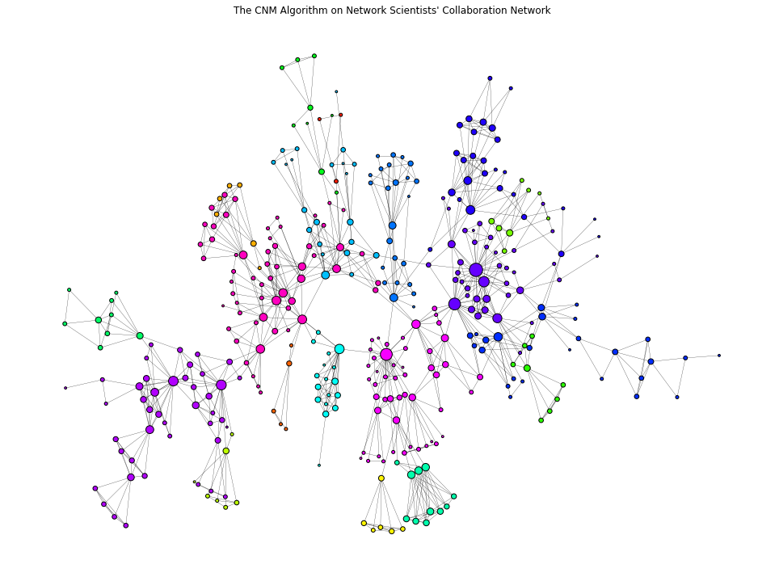

```python
netscience.graph['CNM'] = nx.community.greedy_modularity_communities(netscience)
for c,community in enumerate(netscience.graph['CNM']):
    for n in community:
        netscience.nodes[n]['CNM'] = c
cNum = c+1

plt.figure(figsize=(16,12))
plt.title('The CNM Algorithm on Network Scientists\' Collaboration Network\n')
nx.draw(netscience, pos=netscience.graph['pos'],
        width=.25, edgecolors='k',
        node_size=[k*3000 for k in netscience.graph['degs'].values()],
        node_color=[cmap(c/cNum) for n,c in netscience.nodes(data='CNM')])

print('Number of communities: %d' % cNum)
```

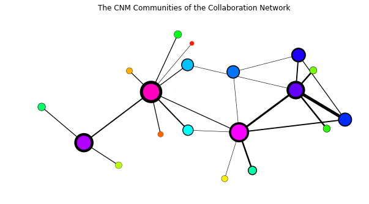

```python
def edges_between(G, U, V):
    return sum(sum(G.has_edge(u, v) for u in U) for v in V)

netscience_CNM = nx.Graph()
for i,Q in enumerate(netscience.graph['CNM']):
    loop = nx.subgraph(netscience, Q).number_of_edges()
    netscience_CNM.add_node(i, size=len(Q), loop=loop)
for i in netscience_CNM:
    for j in range(i):
        ebtw = edges_between(netscience,
                             netscience.graph['CNM'][i],
                             netscience.graph['CNM'][j])
        if ebtw > 0:
            netscience_CNM.add_edge(i, j, weight=ebtw)

netscience_CNM.graph['pos'] = dict((i, np.mean([netscience.graph['pos'][n]
                                                for n in netscience.graph['CNM'][i]],
                                               axis=0)) for i in netscience_CNM)
sMax = max(s for n,s in netscience_CNM.nodes(data='size'))
lMax = max(l for n,l in netscience_CNM.nodes(data='loop'))
wMax = max(w for u,v,w in netscience_CNM.edges(data='weight'))

plt.figure(figsize=(10,5))
plt.title('The CNM Communities of the Collaboration Network\n')
nx.draw(netscience_CNM, pos = netscience_CNM.graph['pos'], edgecolors='k',
        node_size=[s/sMax*1000 for n,s in netscience_CNM.nodes(data='size')],
        node_color=[cmap(c/cNum) for c in netscience_CNM],
        linewidths=[(l/lMax)*5 for n,l in netscience_CNM.nodes(data='loop')],
        width=[(w/wMax)*5 for u,v,w in netscience_CNM.edges(data='weight')])
```

```
Modularity attains its maximum at 18 communities
```

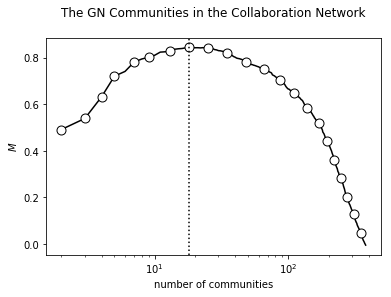

```python
modularities = [modularity(netscience, Qs) for Qs in nx.community.girvan_newman(netscience)]
GN = nx.community.girvan_newman(netscience)
cNum = modularities.index(max(modularities))+2
for i in range(cNum-2): next(GN)
netscience.graph['GN'] = next(GN)

plt.semilogx(range(2, len(modularities)+2), modularities,
             'ko-', ms=9, mfc='w', markevery=.05)
plt.axvline(cNum, c='k', ls=':')
plt.xlabel('number of communities')
plt.ylabel('$M$')
plt.title('The GN Communities in the Collaboration Network\n')

print('Modularity attains its maximum at %d communities' % cNum)
```

```
Number of communities: 18
```

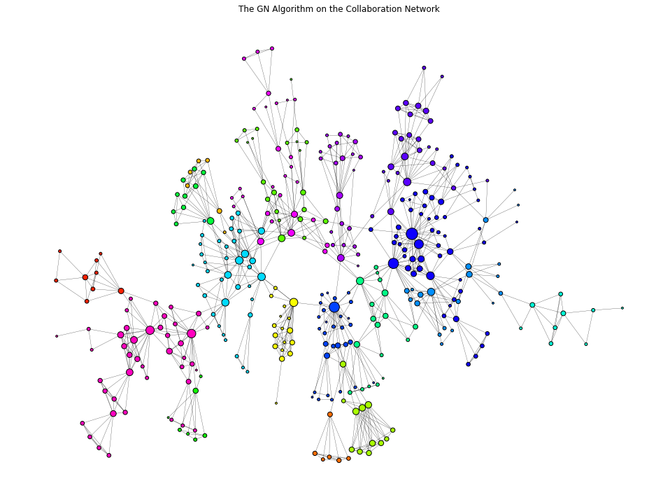

```python
for c,community in enumerate(netscience.graph['GN']):
    for n in community:
        netscience.nodes[n]['GN'] = c
cNum = c+1

plt.figure(figsize=(16,12))
plt.title('The GN Algorithm on the Collaboration Network\n')
nx.draw(netscience, pos=netscience.graph['pos'],
        width=.25, edgecolors='k',
        node_size=[k*3000 for k in netscience.graph['degs'].values()],
        node_color=[cmap(c/cNum) for n,c in netscience.nodes(data='GN')])

print('Number of communities: %d' % cNum)
```

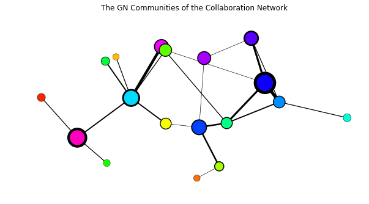

```python
netscience_GN = nx.Graph()
for i,Q in enumerate(netscience.graph['GN']):
    loop = nx.subgraph(netscience, Q).number_of_edges()
    netscience_GN.add_node(i, size=len(Q), loop=loop)
for i in netscience_GN:
    for j in range(i):
        ebtw = edges_between(netscience,
                             netscience.graph['GN'][i],
                             netscience.graph['GN'][j])
        if ebtw > 0:
            netscience_GN.add_edge(i, j, weight=ebtw)

netscience_GN.graph['pos'] = dict((i, np.mean([netscience.graph['pos'][n]
                                               for n in netscience.graph['GN'][i]],
                                              axis=0)) for i in netscience_GN)
sMax = max(s for n,s in netscience_GN.nodes(data='size'))
lMax = max(l for n,l in netscience_GN.nodes(data='loop'))
wMax = max(w for u,v,w in netscience_GN.edges(data='weight'))

plt.figure(figsize=(10,5))
plt.title('The GN Communities of the Collaboration Network\n')
nx.draw(netscience_GN, pos = netscience_GN.graph['pos'], edgecolors='k',
        node_size=[s/sMax*1000 for n,s in netscience_GN.nodes(data='size')],
        node_color=[cmap(c/cNum) for c in netscience_GN],
        linewidths=[(l/lMax)*5 for n,l in netscience_GN.nodes(data='loop')],
        width=[(w/wMax)*5 for u,v,w in netscience_GN.edges(data='weight')])
```

## 4.3 The Louvain algorithm

Blonde et al., who are all from the University of Louvain, Belgium, proposed the Louvain Algorithm, which maximizes modularity in a running time of $\mathcal{O}{\left(N\log{N}\right)}$ [11]. With every node initialized as an individual community, the Louvain algorithm iteratively carries out the following steps:

1. Move node $i$ to the community of one of its neighbours $j$ such that the corresponding change in modularity $\Delta_{ij}$ is positive and maximized. If $\Delta_{ij}<0$ for all $j$, do not move $i$.
2. Repeat step 1 for all $i$ sequentially until $\Delta_{ij}<0$ for all pairs of $\left(i,j\right)$.
3. Transform the original network to a weighted network, in which each node represents a proposed community. The inter-community edges become weighted edges between nodes, whereas the intra-community edges become weighted self-loops; the weights equal to the number of edges.

The three steps form one pass, and the algorithm terminates once the network remains unchanged after step 3. The nodes of the final weighted network represents the potential communities.

Suppose nodes $i$ and $j$ belong to communities $I$ and $J$ before a move. The change in modularity $\Delta_{ij}$ is the sum of the change $\Delta_I^{-i}$ due to removing $i$ from $I$ and the change $\Delta_J^{+i}$ due to adding $i$ to $J$, i.e. $\Delta_{ij}=\Delta_I^{-i}+\Delta_J^{+i}$. On a weighted network with a total weight $W$,

\begin{align} \Delta_J^{+i} = \dfrac{k_i^J}{W} - {\left({\dfrac {w_J+k_i}{2W}}\right)}^2 + \left({\dfrac{w_J}{2W}}\right)^2 + \left({\dfrac{k_i}{2W}}\right)^2 \,, \end{align}

where $k_i$ is the total weight of $i$'s edges, i.e. its weighted degree, and $k_i^J$ the total weight of $i$'s edges linking to nodes in $J$. Then $w_J$ sums up the weighted degrees of nodes in $J$, i.e. $w_J=\sum_{j\in J}{k_j}$. Finally, $\Delta_I^{-i}=-\Delta_{I^\prime}^{+i}$ if $I$ becomes $I^\prime$ after removing $i$.

```python
def louvain(G):
    H = G.copy()
    for c,i in enumerate(H):
        H.nodes[i]['louvain'] = c
    for u,v,w in H.edges(data='weight'):
        H[u][v]['weight'] = 1 if w==None else w

    K_func = lambda i: sum(H[i][j]['weight'] for j in H[i] if j!=i)\
                     + (2*H[i][i]['weight'] if i in H[i] else 0)
    K = dict((i, K_func(i)) for i in H)
    k = lambda i,J: sum(H[i][j]['weight'] for j in H[i] if j in J)
    w = lambda J: sum(K[j] for j in J)

    def delta_J_add_i(i, J):
        ki, wJ = K[i], w(J)
        return k(i,J)/W + (wJ**2+ki**2-(wJ+K[i])**2)/(2*W)**2
    def delta_I_minus_i(i):
        return -delta_J_add_i(i, [j for j in Qs[H.nodes[i]['louvain']] if j!=i])
    def try_to_move(i):
        dImi = delta_I_minus_i(i)
        delta = dict((j, dImi+delta_J_add_i(i,Qs[H.nodes[j]['louvain']])) for j in H[i] if j!=i)
        deltaMax = max(delta.values())
        if deltaMax > 0:
            j = list(delta.keys())[list(delta.values()).index(deltaMax)]
            if H.nodes[i]['louvain'] == H.nodes[j]['louvain']:
                return False
            Qs[H.nodes[i]['louvain']].remove(i)
            Qs[H.nodes[j]['louvain']].add(i)
            H.nodes[i]['louvain'] = H.nodes[j]['louvain']
        else:
            return False

    W = sum(w for u,v,w in H.edges(data='weight'))
    Qs = nx.utils.groups(nx.get_node_attributes(H, 'louvain'))
    move = True
    while move:
        for i in H:
            move = try_to_move(i)

    T = nx.Graph(dict((Q, {}) for Q in Qs if len(Qs[Q])>0))
    for idxI,I in enumerate(T):
        T.add_edge(I, I, weight=sum(H[i][j]['weight'] for i in Qs[I]
                                    for j in H[i] if j in Qs[I]))
        for idxJ in range(idxI):
            J = list(T)[idxJ]
            T.add_edge(I, J, weight=sum(H[i][j]['weight'] for i in Qs[I]
                                        for j in H[i] if j in Qs[J]))

    if nx.is_isomorphic(H, T):
        T.graph['louvain'] = Qs
        return T
    else:
        Qs = louvain(T).graph['louvain']
        for i,L in H.nodes(data='louvain'):
            for Q in Qs:
                if L in Qs[Q]:
                    H.nodes[i]['louvain'] = Q
                    break
        H.graph['louvain'] = nx.utils.groups(nx.get_node_attributes(H, 'louvain'))
        return H
```

```
Number of communities: 21
```

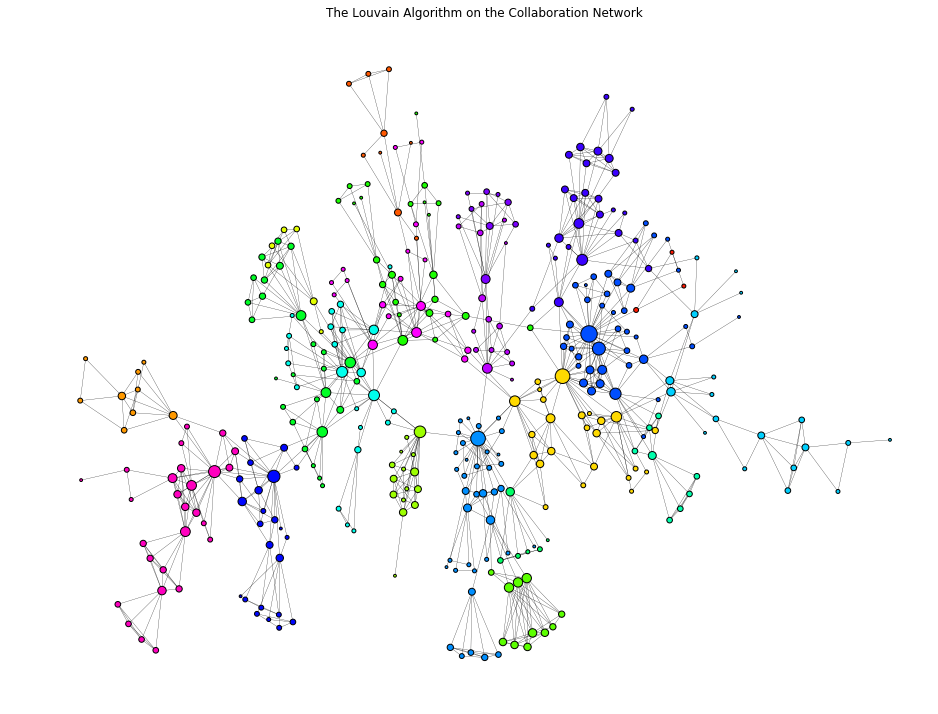

```python
netscience.graph['louvain'] = tuple(louvain(netscience).graph['louvain'].values())
for c,community in enumerate(netscience.graph['louvain']):
    for n in community:
        netscience.nodes[n]['louvain'] = c
cNum = c+1

plt.figure(figsize=(16,12))
plt.title('The Louvain Algorithm on the Collaboration Network\n')
nx.draw(netscience, pos=netscience.graph['pos'],
        width=.25, edgecolors='k',
        node_size=[k*3000 for k in netscience.graph['degs'].values()],
        node_color=[cmap(c/cNum) for n,c in netscience.nodes(data='louvain')])

print('Number of communities: %d' % cNum)
```

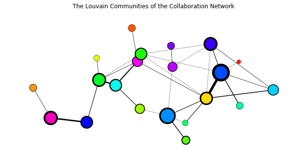

```python
netscience_louvain = nx.Graph()
for i,Q in enumerate(netscience.graph['louvain']):
    loop = nx.subgraph(netscience, Q).number_of_edges()
    netscience_louvain.add_node(i, size=len(Q), loop=loop)
for i in netscience_louvain:
    for j in range(i):
        ebtw = edges_between(netscience,
                             netscience.graph['louvain'][i],
                             netscience.graph['louvain'][j])
        if ebtw > 0:
            netscience_louvain.add_edge(i, j, weight=ebtw)

netscience_louvain.graph['pos'] = dict((i, np.mean([netscience.graph['pos'][n]
                                                    for n in netscience.graph['louvain'][i]],
                                                   axis=0)) for i in netscience_louvain)
sMax = max(s for n,s in netscience_louvain.nodes(data='size'))
lMax = max(l for n,l in netscience_louvain.nodes(data='loop'))
wMax = max(w for u,v,w in netscience_louvain.edges(data='weight'))

plt.figure(figsize=(10,5))
plt.title('The Louvain Communities of the Collaboration Network\n')
nx.draw(netscience_louvain, pos = netscience_louvain.graph['pos'], edgecolors='k',
        node_size=[s/sMax*1000 for n,s in netscience_louvain.nodes(data='size')],
        node_color=[cmap(c/cNum) for c in netscience_louvain],
        linewidths=[(l/lMax)*5 for n,l in netscience_louvain.nodes(data='loop')],
        width=[(w/wMax)*5 for u,v,w in netscience_louvain.edges(data='weight')])
```

## 4.4 Resolution limit of modularity

Before ending, we must discuss the major drawback of using modularity: it almost prohibits the existence of small communities due to its resolution limit, while there are no physical reasons to ban them. In fact, if we merge two communities $A$ and $B$ that have total degrees $K_A$ and $K_B$, the resulting change in modularity reads

\begin{align} \Delta_{AB} &= \dfrac{E_{AB}}{E} - \dfrac{K_AK_B}{2E^2} \\ &\sim E_{AB} - \dfrac{K_AK_B}{2E} \,, \end{align}

where the two communities are connected with $E_{AB}$ edges. Once $K_AK_B<2E$, the change $\Delta_{AB}$ is positive as long as at least one edge connects $A$ and $B$, i.e. $E_{AB}=1$. This physically means that a network's modularity can be increased by merging two barely connected small communities. Consequently, a communitity with a total degree $K<\sqrt{2E}$ cannot be observed through modularity maximization. In other words, a network probably has fewer large communities but more small communities than what modularity maximization suggests.

# References

1. De Nooy, W., Mrvar, A. Batagelj, V.: Exploratory Social Network Analysis with Pajek. Cambridge University Press, Cambridge (2005).
2. Zacahary, W. W.: An Information Flow Model for Conflict and Fission in Small Groups. J. Anthropol. Res. 33 (4), 452–473 (1977).
3. Girvan, M., Newman, M. E. J.: Community structure in social and biological networks. Proc. Natl. Acad. Sci. U.S.A., 99, 7821–7826 (2002).
4. Lusseau, D., Schneider, K., Boisseau, O. J., Haase P., Slooten, E., Dawson S. M.: The bottlenose dolphin community of Doubtful Sound features a large proportion of long-lasting associations. Behav. Ecol. Sociobiol. 54, 396–405 (2003).
5. Newman, M. E. J.: Finding community structure in networks using the eigenvectors of matrices. Phys. Rev. E 74, 036104 (2006).
6. Kernighan, B. W., Lin, S.: An efficient heuristic procedure for partitioning graphs. Bell Syst. Tech. J. 49, 291–307 (1970).
7. Ravasz E., Somera A. L., Mongru D. A., Oltvai Z. N., Barabási, A.-L.: Hierarchical organization of modularity in metabolic networks. Science 297, 1551–1555 (2002).
8. Barabási, A.-L.: Network Science. Cambridge Univeristy Press, Cambridge (2016).
9. Newman, M. E. J.: Fast algorithm for detecting community structure in networks. Phys. Rev. E 69, 066133 (2004).
10. Clauset A., Newman M. E. J., Moore C.: Finding community structure in very large networks. Phys. Rev. E 70, 066111 (2004).
11. Blondel V. D., Guillaume J.-L., Lambiotte R., Lefebvre E.: Fast unfolding of communities in large networks. J. Stat. Mech. 2008, P10008 (2008).